# HTML report Pipeline Quantification Summary

Jishu Xu

30 May, 2018

# Purpose

In this section, we will compare and summary the quantification matrix by the following way * set up threshold, for example TPM > 15 or CNT>10 as detectable * set up threshold, for example, TPM <5 or CNT <5 as not-detectable * compare two data matrix in term of their detectable and un-detectable genes. particulary those gene which are detectacble in one but not detectacble in another * summary those “inconsisttant genes” by gene biotype

# Input data

The key input data for this test are the data matrix generated by two pipelines, they can be gene counts matrix or TPM, FPKM matrix. The detail of input data are listed below

- matrix1: data matrix from pipeline, such as base pipeline.
- matrix2: data matrix from pipeline, such as updated pipeline.
- gtf_file: gene annotation file in gtf format.
- metadata_file: meta information about cells, such as cell type.
- output_prefix: output prefix or output name.

First load functions we will use in this test

```r
source("analysis_functions.R")
```

Here is the list of input parameters

```r
option_list <- list(
  make_option(
    "--matrix1",
    type = "character",
    default = NULL,
    help = "data matrix file name",
    metavar = "character"
  ),
  make_option(
    "--matrix2",
    type = "character",
    default = NULL,
    help = "updated data matrix file name",
    metavar = "character"
  ),
  make_option(
    "--gtf_file",
    type = "character",
    default = NULL,
    help = "gtf annotation file",
    metavar = "character"
  ),
  make_option(
    "--groups",
    type = "character",
    default = NULL,
    help = "key id in meta data for t-test",
    metavar = "character"
  ),
  make_option(
    "--metadata_file",
    type = "character",
    default = NULL,
    help = "metadata file",
    metavar = "character"
  ),
  make_option(
    "--low_cut",
    type = "character",
    default = NULL,
    help = "low cutoff threshold",
    metavar = "character"
  ),
  make_option(
    "--high_cut",
    type = "character",
    default = NULL,
    help = "high cutoff threshold",
    metavar = "character"
  ),
  make_option(
    "--output_prefix",
    type = "character",
    default = NULL,
    help = "output prefix",
    metavar = "character"
  )
)
args<-strsplit(commandArgs(trailingOnly = TRUE),split=' ')
opt_parser <- OptionParser(option_list = option_list)
opt <- parse_args(opt_parser,args=args[[1]])
matrixfile1 <- opt$matrix1
matrixfile2 <- opt$matrix2
gtf_file <-  opt$gtf_file
locut<-opt$low_cut
hicut<-opt$high_cut
output_name <- opt$output_prefix
```

# Parse Inputs

## Load Data Matrix

Data matrix files are *.csv file and can be count, TPM or FPKM matrix. For benchmarking purpose, TPM would be optimal choice.

```r
# load matrix file
mat1 <- read.csv(matrixfile1)
mat2 <- read.csv(matrixfile2)
rownames(mat1)<-mat1[,1]
rownames(mat2)<-mat2[,1]
# transfor matrix to 1/0 values based on threshold
mat1.d <- digitalizeMat(mat1[,-c(1:2)],locut,hicut)
mat2.d <- digitalizeMat(mat2[,-c(1:2)],locut,hicut)
```

match matrix by header

```r
colnames(mat1.d)<-colnames(mat1[,-c(1:2)])
colnames(mat2.d)<-colnames(mat2[,-c(1:2)])
rownames(mat1.d)<-rownames(mat1)
rownames(mat2.d)<-rownames(mat2)
mlist<-match(colnames(mat1.d),colnames(mat2.d))
mat2.d<-mat2.d[,mlist]
```

Load gene annotation

```r
genes <- ParseGene(gtf_file)
```

# Discrepency between two data matrix

Here we simply do subtraction between two matrix and will look for the subtraction equal to 2 or equal to -2

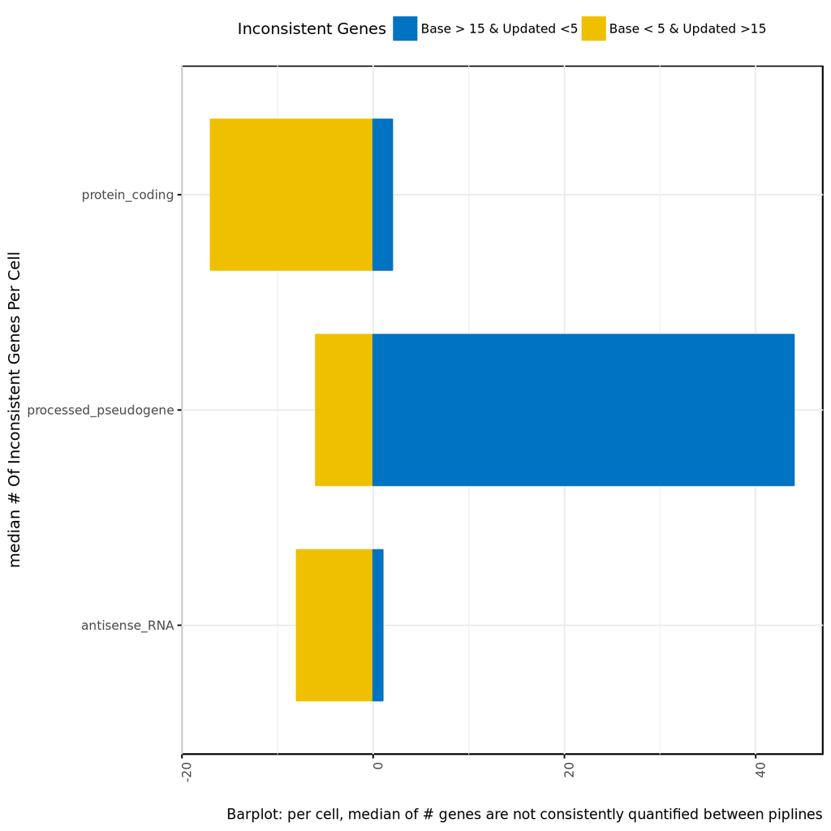

```r
dsub<-mat1.d -  mat2.d
sumb1<-SummaryQuantificationByType(dsub,genes,2)
sumb2<-SummaryQuantificationByType(dsub,genes,-2)
sumb1.m<-apply(sumb1[,-1],1,median)
sumb2.m<-apply(sumb2[,-1],1,median)
tot<-cbind(sumb1.m,-1*sumb2.m)
rownames(tot)<-sumb1$biotype
tot.sub<-subset(tot,tot[,1]>0 & tot[,2]<0)
colnames(tot.sub)<-c(paste("Base > ",hicut," & Updated <",locut,sep=""),paste("Base < ",locut," & Updated >",hicut,sep=""))
mtb<-melt(tot.sub)
pb <- ggbarplot(
  mtb,
  x = 'Var1',
  y = 'value',
  color = "Var2",
  fill = "Var2",
  # change fill color by FC
  x.text.angle = 90,
  # Rotate vertically x axis texts
  xlab = "median # Of Inconsistent Genes Per Cell",
  ylab = "",
  rotate = TRUE,
  caption = "Barplot: per cell, median of # genes are not consistently quantified between piplines",
  ggtheme = theme_minimal(),
  palette = "jco",
  legend.title = "Inconsistent Genes",
  legend = "top"
) + border()
pb
```